# Eelgrass_community_structure_analyses_SEM

Wendel Raymond

October 4, 2018

# An SEM approach to eelgrass communities in southeast Alaska

As an alternative to using only limear models we may also be able to describe the eelgrass community structure with strutual equation modeling (SEM). This will follow the apprach and package developed by [Lefcheck](https://jonlefcheck.net/2014/07/06/piecewise-structural-equation-modeling-in-ecological-research/). All of the pre data processing will follow that same as the glm models in other scripts.

## Data

**Response metrics** 1. eelgrass aboveground biomass density (g / m<sup>2</sup>) 2. eelgrass belowground biomass density (g / m<sup>2</sup>) 3. eelgrass shoot density (count / m<sup>2</sup>) 4. ratio of aboveground to belowground biomass density (g / m<sup>2</sup>) 5. epiphyte load (g epiphyte / g eelgrass) 6. total grazer load (g grazers/ g eelgrass) + gastropod load (g grazers/ g eelgrass) + crustaecean load (g grazers/ g eelgrass) 7. crab biomass (g) - can also be counts 8. fish biomass (g) - can also be counts

**Explanatory factors** 1. Sea otter index 2. Time 3. Sediment type (primary sediment type from the “inside” eelgrass transect) 4. Light attenuation 5. crab biomass (g) 6. fish biomass (g) 7. grazer load (g/g) 8. epiphyte load (g/g)

### Data Prep

Sediment data preparation. Average by site.

Light availability calculation

Crab data preparation. This needs to be done to summarise by site and string (i.e. loose species information). Average by site.

Crab data preparation. Summarize counts and mass of cancer/rock crabs. Average by site.

Fish data preparation. append taxonomy

This needs to be done to summarise by site across all species.

## Analytical Approach

*Question* Does a sea otter mediated trophic cascade occur in Southeast Alaska? What are the relationships among eelgrass community constiuents, and do sea otters play a role in that?

Analysis will follow four major steps.

1. Define a conceptual model that shows all biologically defenseable paths among variables.
2. Reduce the possible varibles to ones that actually seem important for describing the relationship among variables.
3. Adjust the conceptual model to incule only those varibles which were deemed important from above.
4. Fit SEM

For our analysis we will first define our exogenous and endogenous variables.

*Exogenous* - varibles that only have paths going away from them 1. Sea otters 2. Nutrients 3. Light availability 4. Sediment 5. Time - kinda, but we will deal with that later

*Endogenous* - variables that have paths coming to them and potentially going away from them 1. Crabs 2. Fish 3. Grazers 4. Epiphytes 5. Eelgrass

### 1. Conceptual model

Diagram represents all reasonable direct biological paths among the eelgrass associated community.

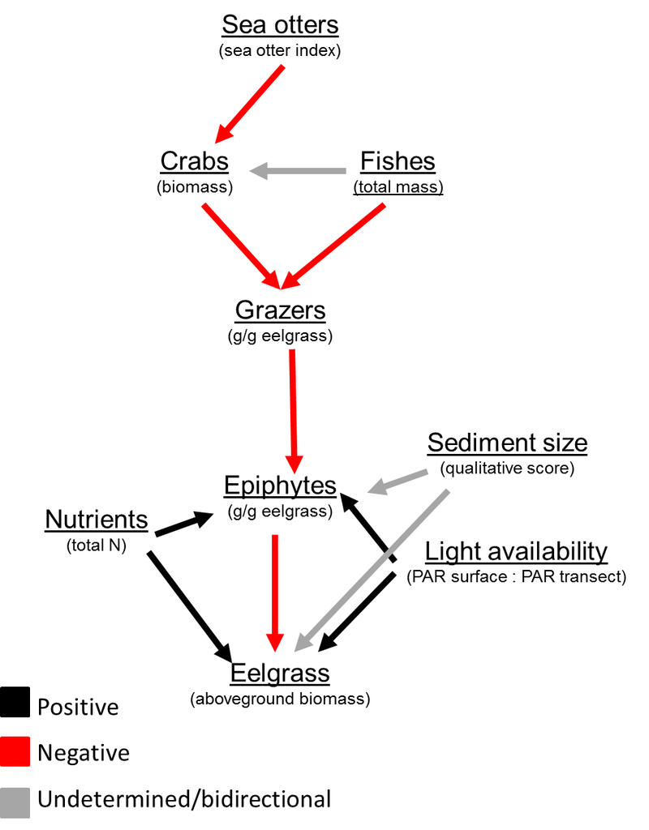

### 2. Suitable data and variable reduction

Following the rule of thumb that any responce of one of the component models should have 5 >= N/5 predictors, we will evaluate potential component models. For our data set we have N = 21 so 21/5 = 4.2, so any componenet model should have no more than 4 predictors. Looking at the conceptual model no endogenous variables have more than 4 paths going towards them, indicating that we have aduaquate data to fit all the paths. So thats good.

Grace at al 2012 is of the opinion of keeping models simple and tightly defining your question. I tend to agree, especailly considering the low sample size of the study.

### 3. Addressing normality and temporal trends

To meet normality assumptions we will evaluate the data distribution and normality of for exogeneous and endogenous varibles.

#### Exogeneous data normality

Sea otter index. Is somewhat non-normal in its distribution, however tranforming these data (PC1 values) does not make sense. We will proceed with values untransformed.

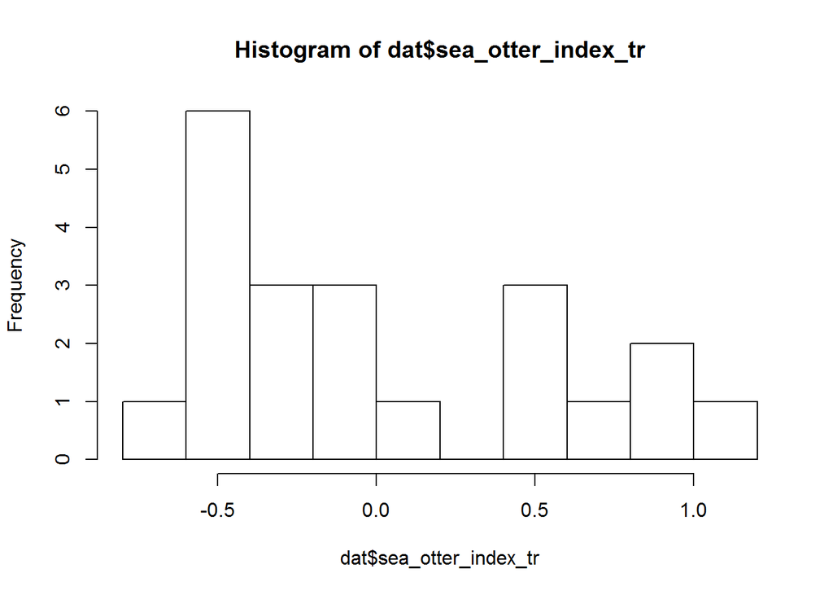

Nutrients. Is somewhat non-normal. Transformations do not improve it much. These data are just really variable. We will proceed with values untransformed.

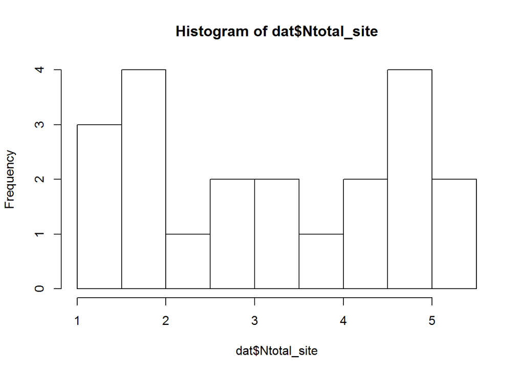

Light availability. Is reasonably normal. We will proceed with values untransformed.

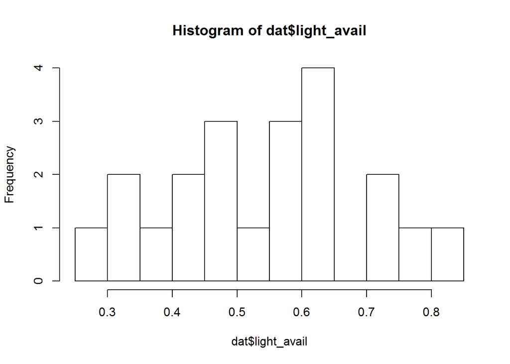

Semdiment size. Is non-normal. This is driven by a lot of low values. We will proceed with values untransformed.

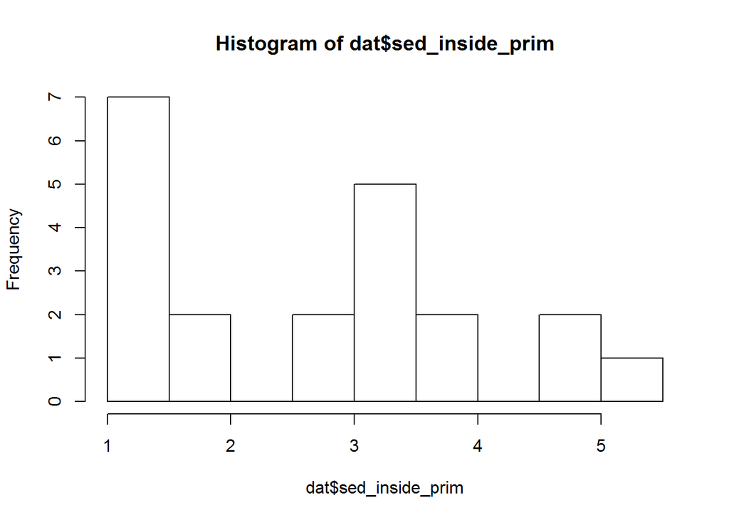

#### Endogenous data normality

Aboveground eeglrass biomass. Is slightly reasonably normal. We will proceed with values untransformed.

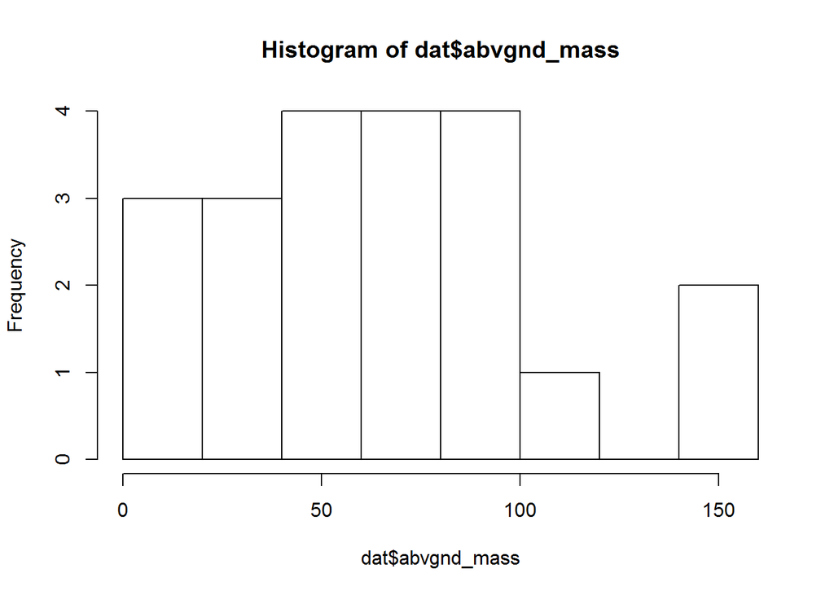

Epiphyte load. Is non-normal. We will proceed with a *log transformation of epiphyte load*.

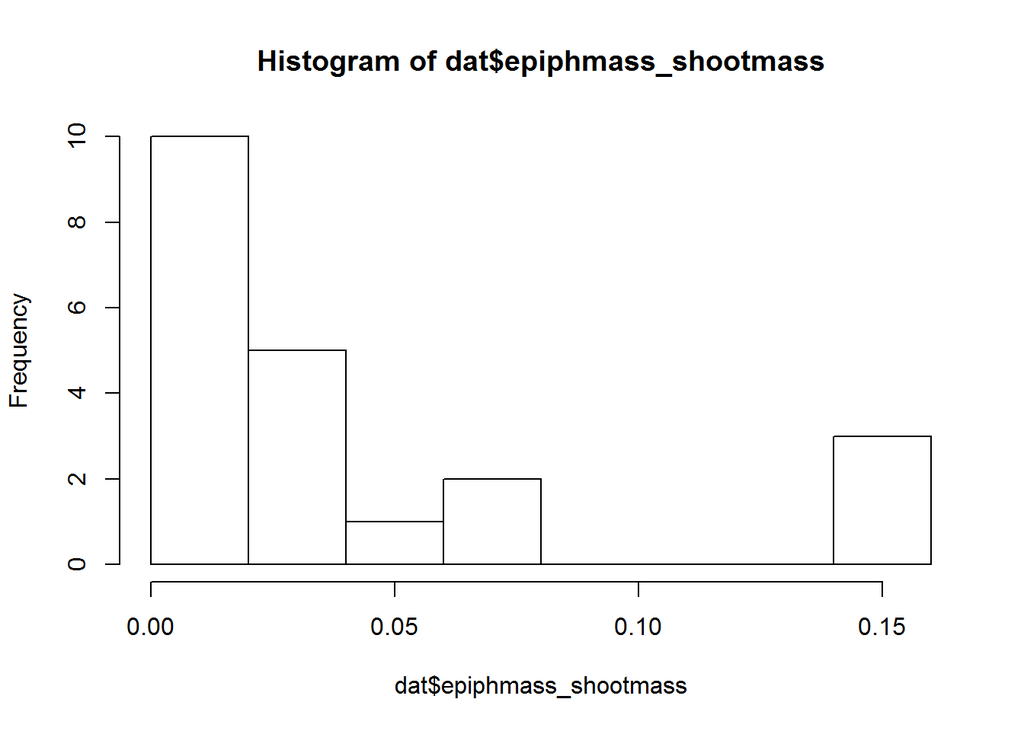

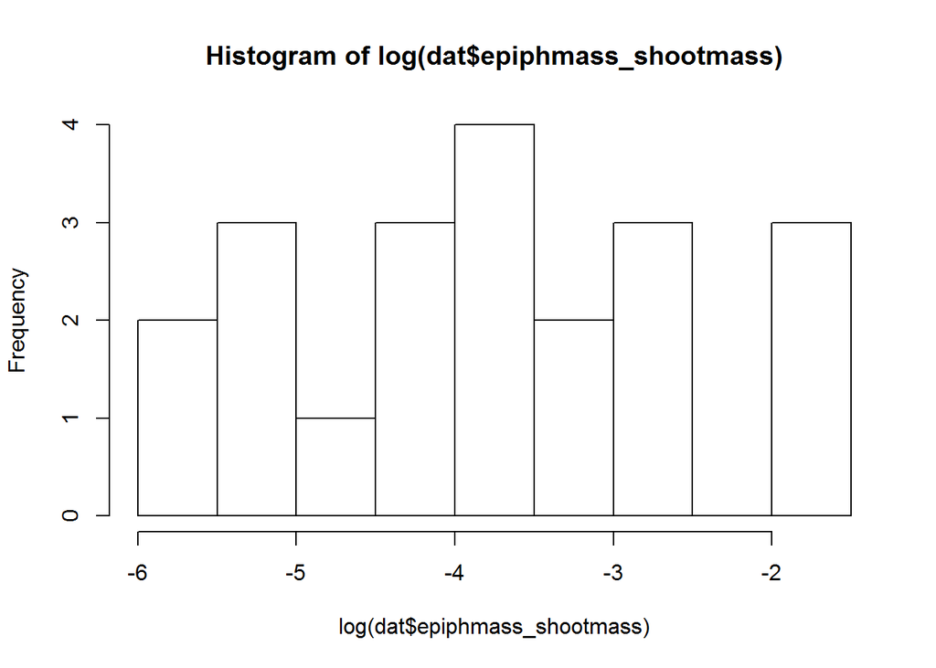

Grazer load. Is non-normal. We will proceed with a *log transformation of grazer load*.

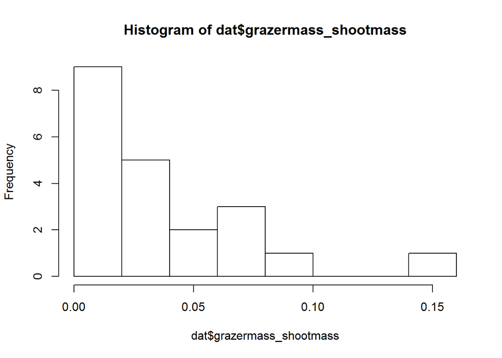

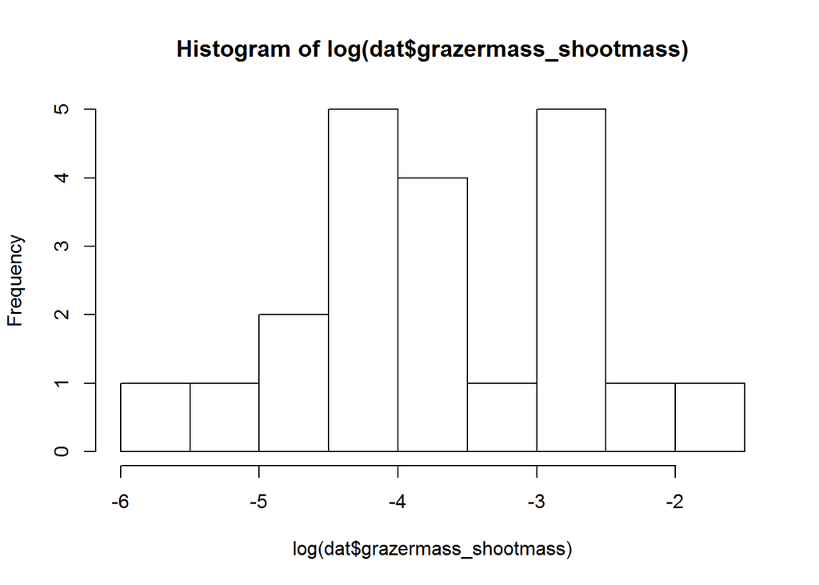

Fish total mass. Is non-normal. We will proceed with a *log transformation of fish biomass*.

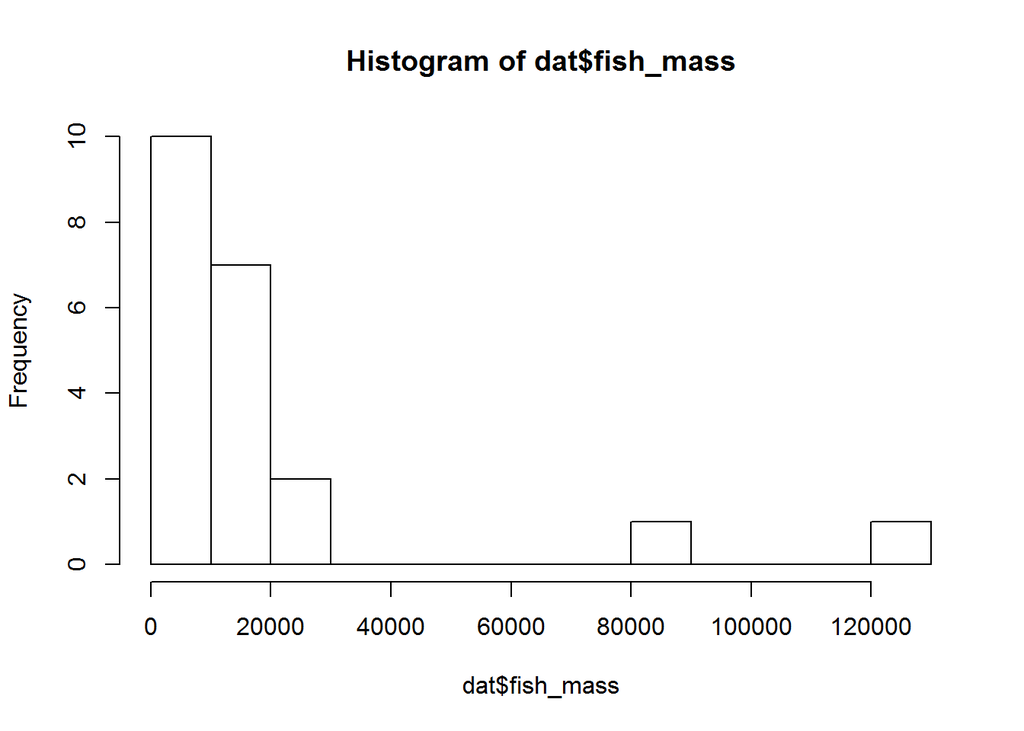

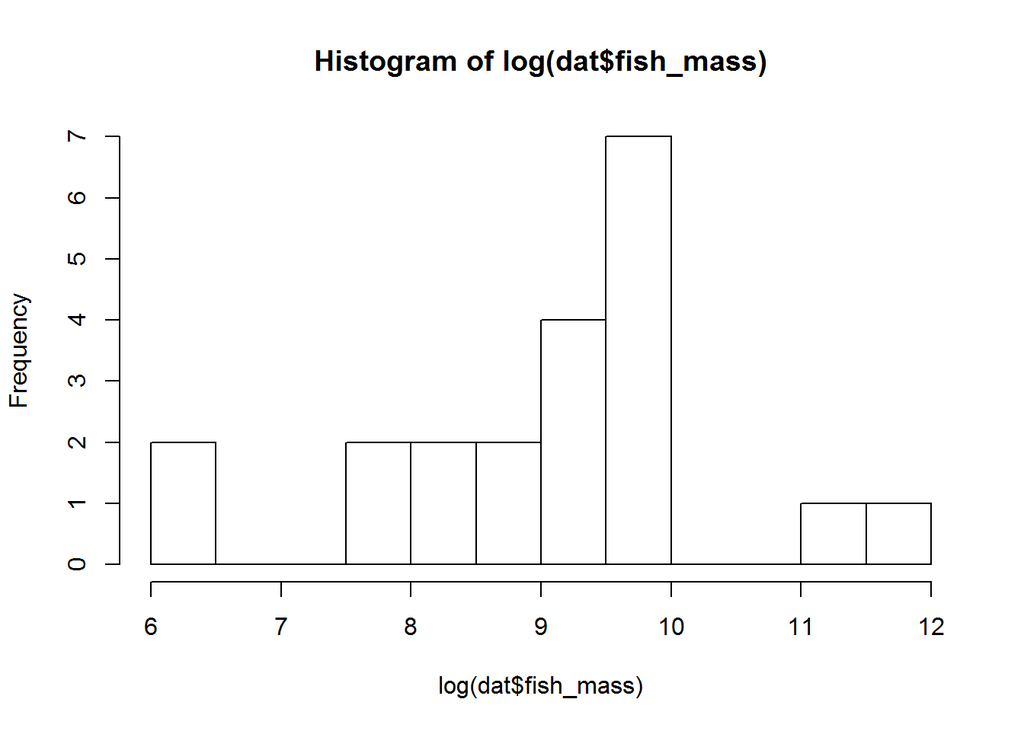

Crab total mass. Is non-normal. We will procees with a *square root transfromation of crab biomass*.

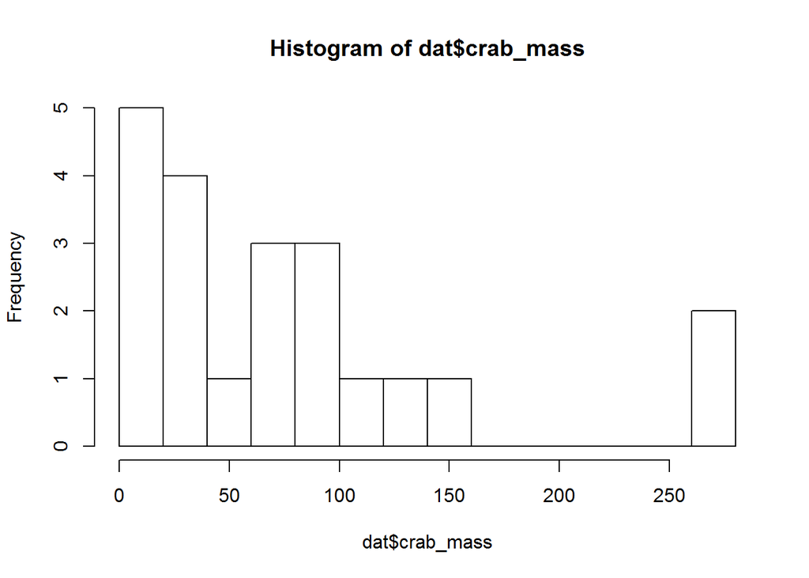

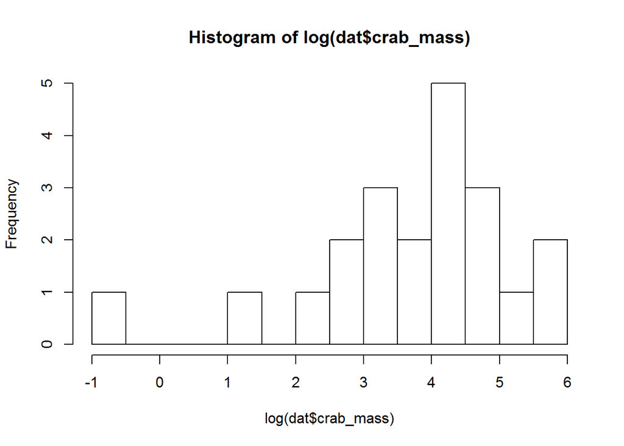

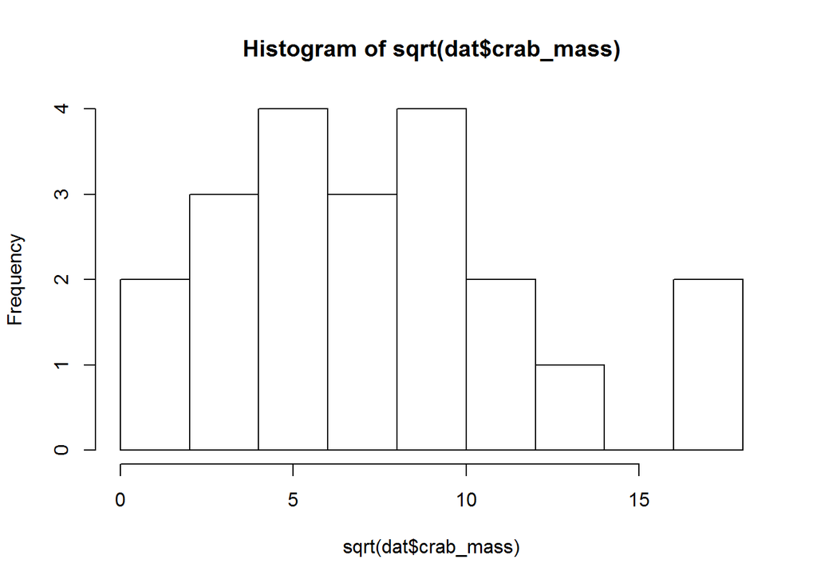

Macroalgae percent cover. Is non-normal. Transformations do not do that much. Considering that its percent cover data we will proceed with a *asin(sqrt()) transformation*.

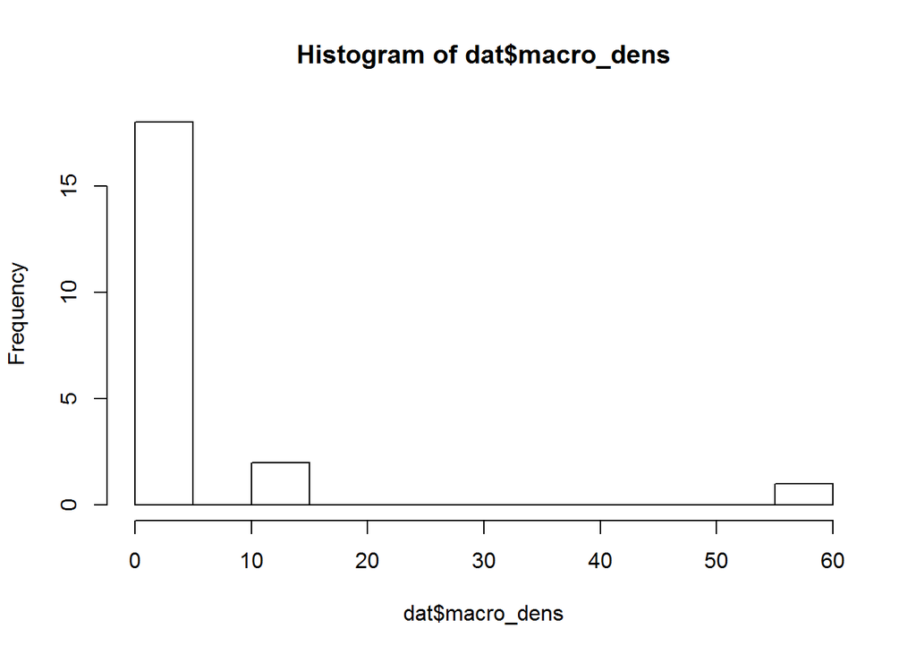

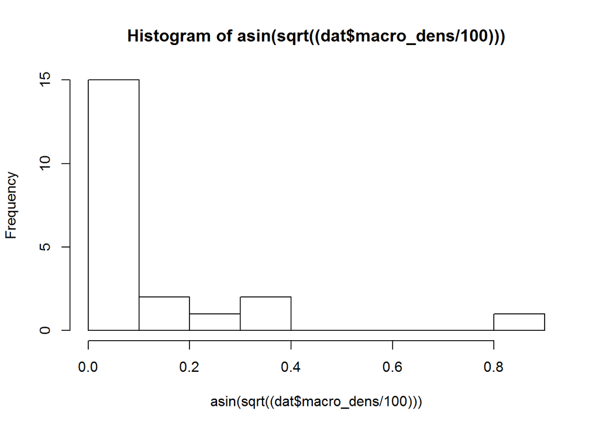

Diatom percent cover. Is non-normal. Transformations do not do that much. Considering that its percent cover data we will proceed with a *asin(sqrt()) transformation*.

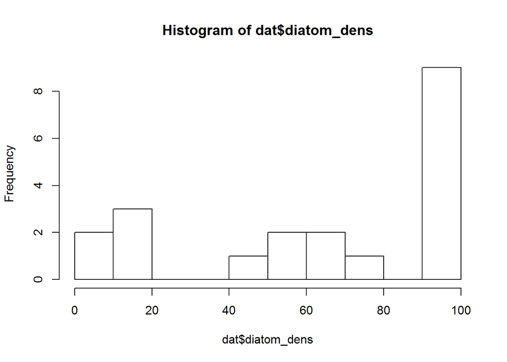

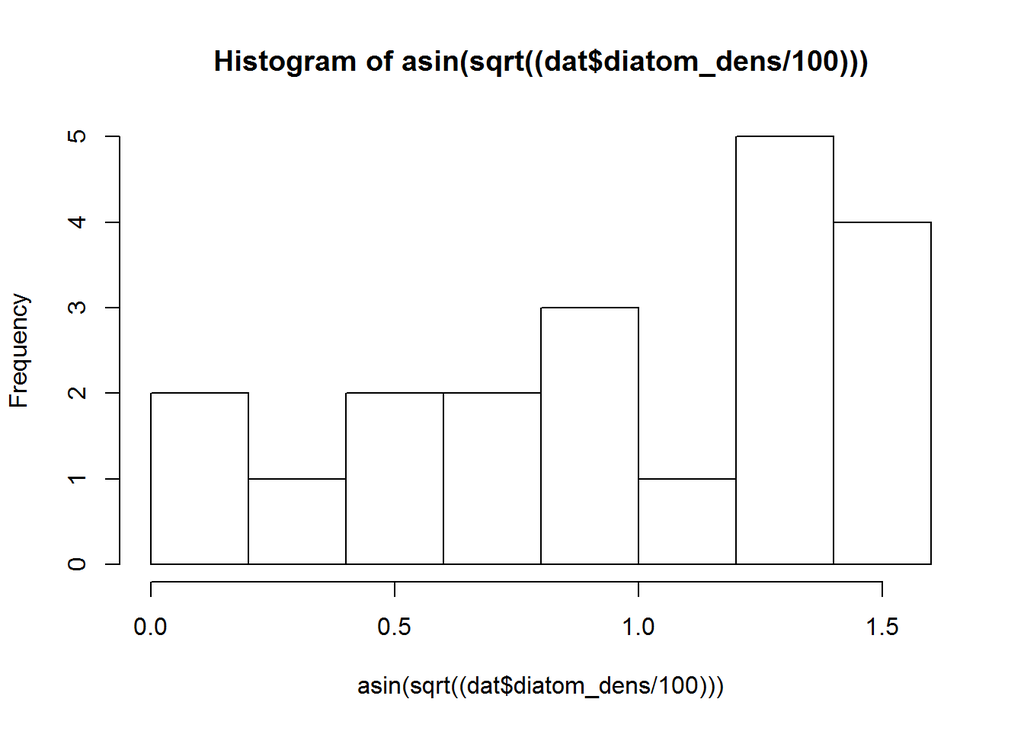

#### Temporal change

Eelgrass aboveground biomass has a strong temporal signal. *Eelgrass aboveground biomass will be de-trended*.

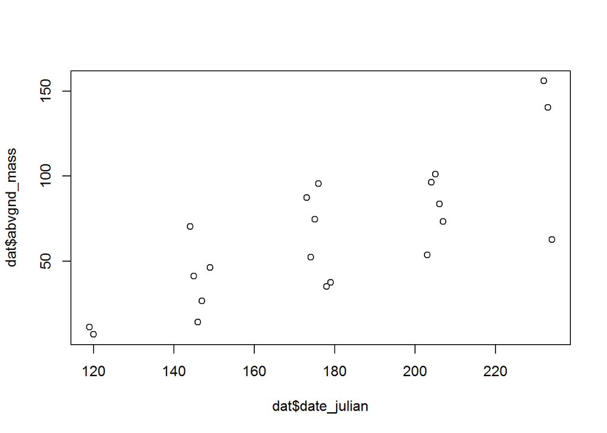

```
##
## Call:
## lm(formula = dat$abvgnd_mass ~ dat$date_julian)
##
## Residuals:
##     Min      1Q  Median      3Q     Max
## -50.718 -16.678  -2.007  13.105  44.274
##
## Coefficients:
##                 Estimate Std. Error t value Pr(>|t|)
## (Intercept)     -90.6921    29.8781  -3.035  0.00681 **
## dat$date_julian   0.8722     0.1644   5.307 4.03e-05 ***
## ---
## Signif. codes:  0 '***' 0.001 '**' 0.01 '*' 0.05 '.' 0.1 ' ' 1
##
## Residual standard error: 25.83 on 19 degrees of freedom
## Multiple R-squared:  0.5971, Adjusted R-squared:  0.5759
## F-statistic: 28.16 on 1 and 19 DF,  p-value: 4.026e-05
```

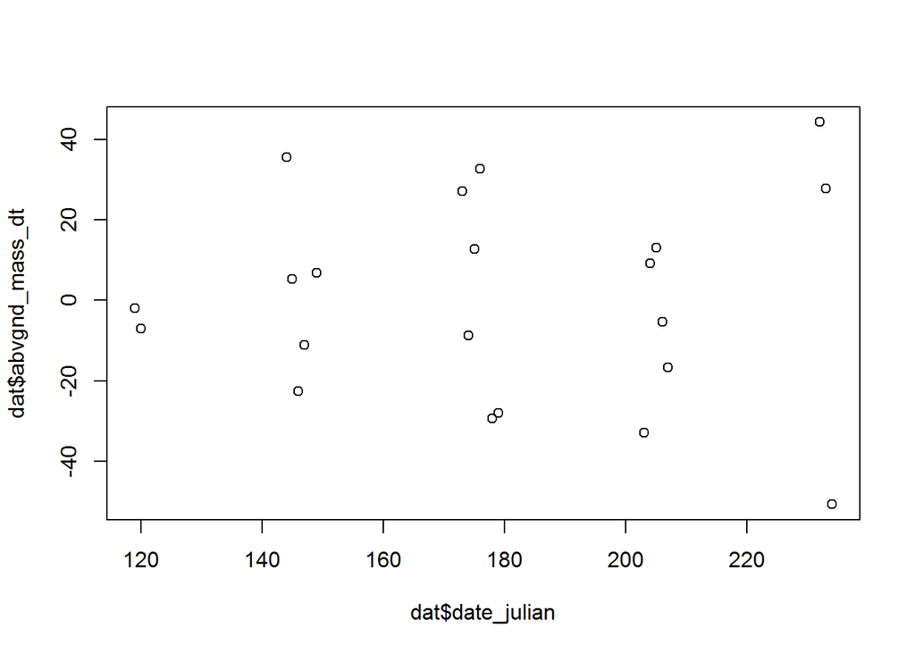

Epiphyte load has a significant negative relationships with epiphyte load. *epiphyte load will be de-trended*.

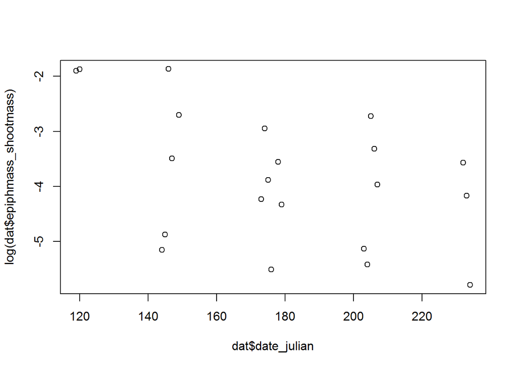

```
##
## Call:
## lm(formula = log(dat$epiphmass_shootmass) ~ dat$date_julian)
##
## Residuals:
##     Min      1Q  Median      3Q     Max
## -1.8857 -0.9050  0.2652  0.9580  1.5342
##
## Coefficients:
##                 Estimate Std. Error t value Pr(>|t|)
## (Intercept)      -0.9361     1.2725  -0.736    0.471
## dat$date_julian  -0.0162     0.0070  -2.314    0.032 *
## ---
## Signif. codes:  0 '***' 0.001 '**' 0.01 '*' 0.05 '.' 0.1 ' ' 1
##
## Residual standard error: 1.1 on 19 degrees of freedom
## Multiple R-squared:  0.2198, Adjusted R-squared:  0.1787
## F-statistic: 5.353 on 1 and 19 DF,  p-value: 0.03204
```

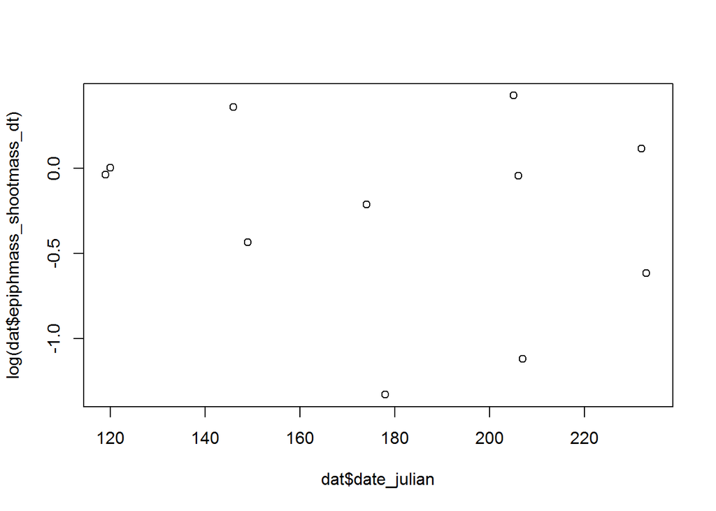

Grazer load looks like it may have a temporal signal but its turns out that its not significant and has a low R-sq value.

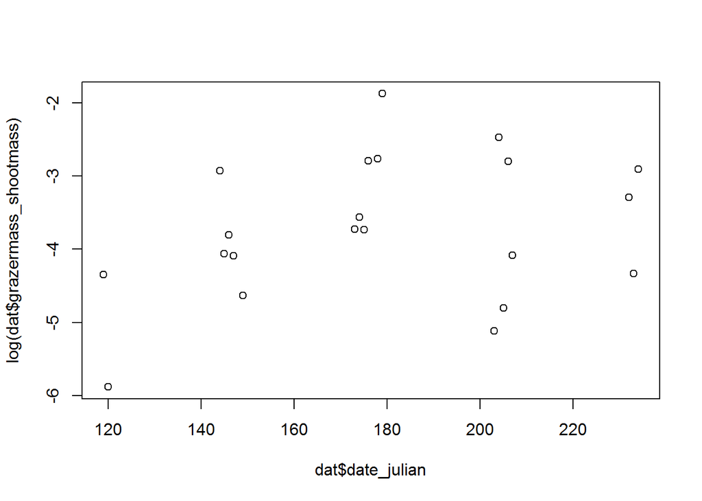

```
##
## Call:
## lm(formula = log(dat$grazermass_shootmass) ~ dat$date_julian)
##
## Residuals:
##      Min       1Q   Median       3Q      Max
## -1.67922 -0.60349  0.01207  0.68940  1.83433
##
## Coefficients:
##                  Estimate Std. Error t value Pr(>|t|)
## (Intercept)     -5.196979   1.099411  -4.727 0.000147 ***
## dat$date_julian  0.008306   0.006048   1.373 0.185617
## ---
## Signif. codes:  0 '***' 0.001 '**' 0.01 '*' 0.05 '.' 0.1 ' ' 1
##
## Residual standard error: 0.9504 on 19 degrees of freedom
## Multiple R-squared:  0.09031,    Adjusted R-squared:  0.04243
## F-statistic: 1.886 on 1 and 19 DF,  p-value: 0.1856
```

Crabmass

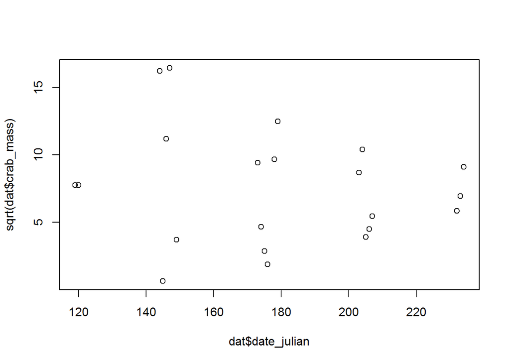

Macroalgae

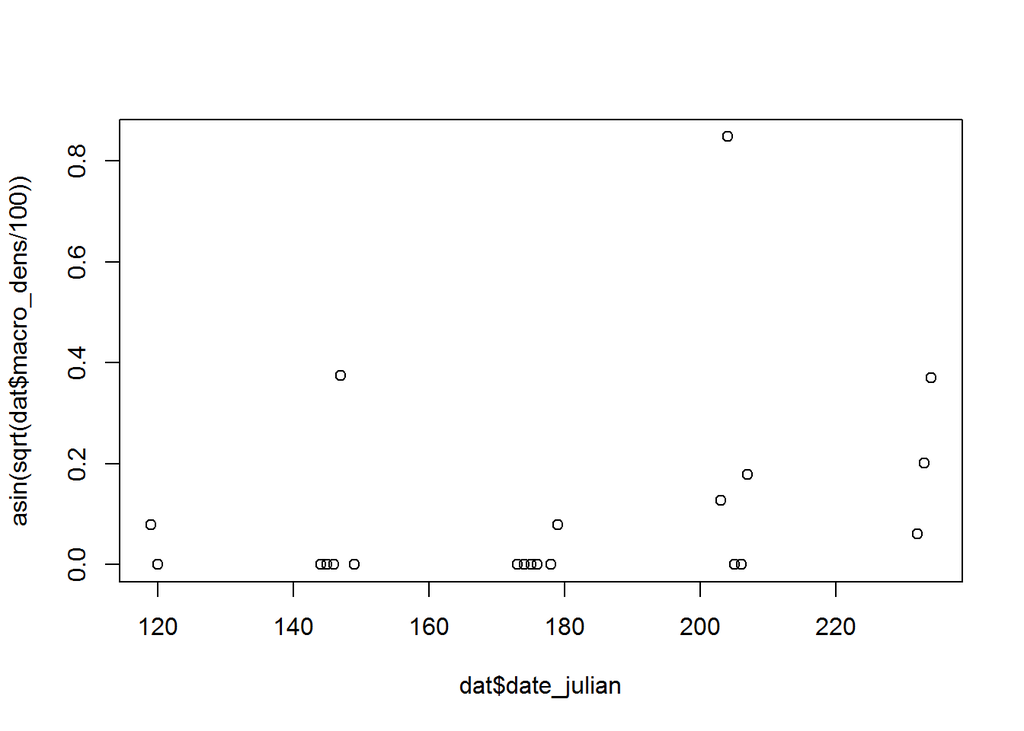

```
##
## Call:
## lm(formula = asin(sqrt(dat$macro_dens/100)) ~ dat$date_julian)
##
## Residuals:
##      Min       1Q   Median       3Q      Max
## -0.16401 -0.10359 -0.04513  0.00359  0.68795
##
## Coefficients:
##                  Estimate Std. Error t value Pr(>|t|)
## (Intercept)     -0.237455   0.230060  -1.032    0.315
## dat$date_julian  0.001949   0.001266   1.540    0.140
##
## Residual standard error: 0.1989 on 19 degrees of freedom
## Multiple R-squared:  0.111,  Adjusted R-squared:  0.06417
## F-statistic: 2.371 on 1 and 19 DF,  p-value: 0.1401
```

Diatoms have a reasonable correlation with time. *Diatom percent cover will we detrended*

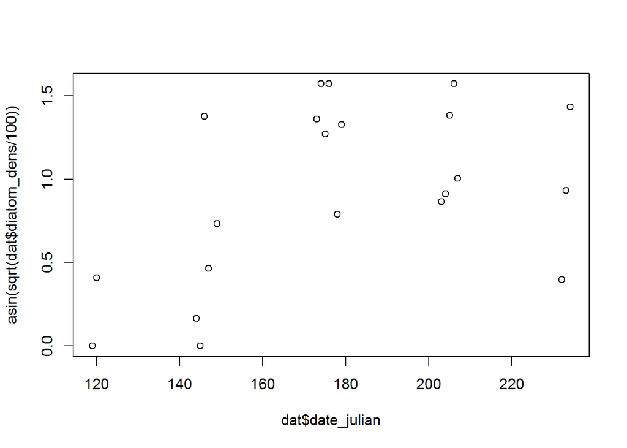

```
##
## Call:
## lm(formula = asin(sqrt(dat$diatom_dens/100)) ~ dat$date_julian)
##
## Residuals:
##     Min      1Q  Median      3Q     Max
## -0.9020 -0.2486 -0.1159  0.3926  0.6719
##
## Coefficients:
##                  Estimate Std. Error t value Pr(>|t|)
## (Intercept)     -0.303584   0.551576  -0.550   0.5885
## dat$date_julian  0.006911   0.003034   2.278   0.0345 *
## ---
## Signif. codes:  0 '***' 0.001 '**' 0.01 '*' 0.05 '.' 0.1 ' ' 1
##
## Residual standard error: 0.4768 on 19 degrees of freedom
## Multiple R-squared:  0.2145, Adjusted R-squared:  0.1731
## F-statistic: 5.188 on 1 and 19 DF,  p-value: 0.0345
```

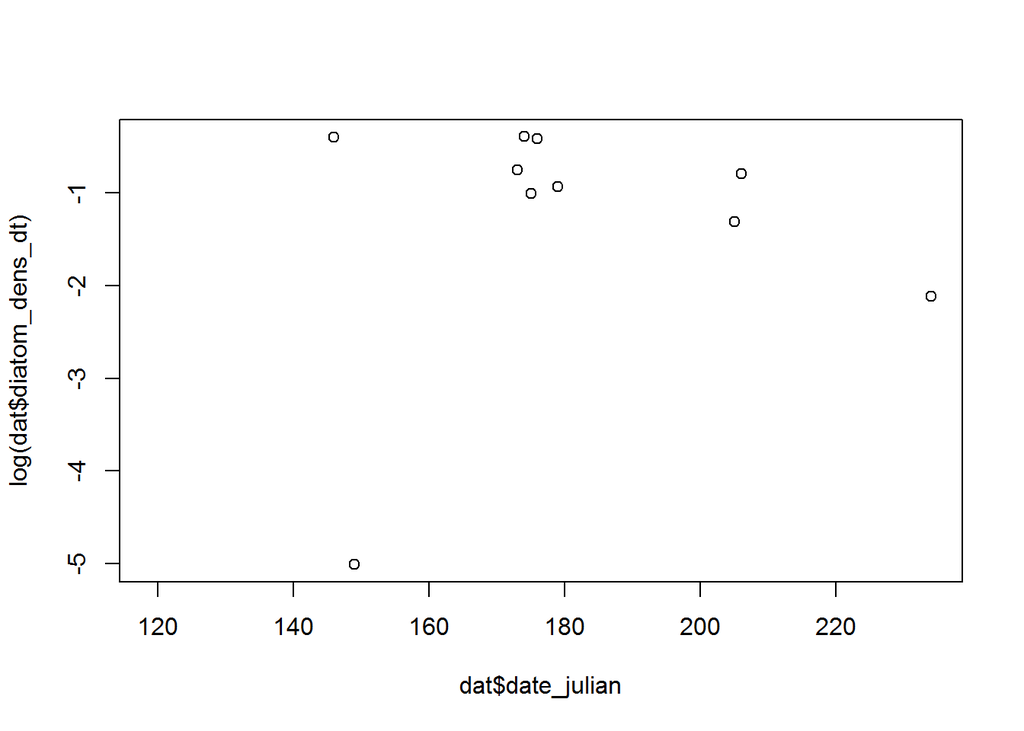

### 4. Set of structural equations

#### Final variable set for full model

*Exogeneous* 1. Sea otters 2. Total water nitrogen 3. Light availability 4. Sediment

*Endogeneous* 1. Eelgrass (as abovegound biomass - de-trended with respect to julian day) 2. Epiphytes (as epiphte load - log trasformed and de-trended with respect to julian day) 3. Grazers (as grazer load - log transformed) 4. Fish (as total fish biomass - log tranformed) 5. Crabs (as total crab biomass - square-root transformed)

#### Simplified data

To simplify the analysis work space I will create a new data frame with all the data I am going to use in its final form. So tranfromed and de-trended where appropriate.

#### 5. Full SEM

##### SEM 1

Following paths indicated in figure

```r
sem.1 <- psem(
  lm(crab_mass_sq ~ sea_otter_index_tr + fish_mass_ln, data = dat.redu),

  lm(grazermass_shoot_ln ~ crab_mass_sq + fish_mass_ln, data = dat.redu),

  lm(epiphmass_shootmass_ln_dt ~ grazermass_shoot_ln + sed_inside_prim + Ntotal_site + light_avail, data = dat.redu),

  lm(abvgnd_mass_dt ~ epiphmass_shootmass_ln_dt + sed_inside_prim + Ntotal_site + light_avail, data = dat.redu)

)
```

###### Model checking and diagnostics

Below we will run through model components and diagnostics.

###### Basis Set

###### d-seperation

No evidence of any d-separation

```
##                                            Independ.Claim    Estimate
## 1        grazermass_shoot_ln  ~  sea_otter_index_tr + ... -0.17621453
## 2  epiphmass_shootmass_ln_dt  ~  sea_otter_index_tr + ...  0.20759550
## 3             abvgnd_mass_dt  ~  sea_otter_index_tr + ... 21.39346938
## 4        epiphmass_shootmass_ln_dt  ~  fish_mass_ln + ...  0.07624657
## 5                   abvgnd_mass_dt  ~  fish_mass_ln + ... -5.31087302
## 6                  crab_mass_sq  ~  sed_inside_prim + ...  0.43661200
## 7           grazermass_shoot_ln  ~  sed_inside_prim + ... -0.13610085
## 8                      crab_mass_sq  ~  Ntotal_site + ...  0.16803730
## 9               grazermass_shoot_ln  ~  Ntotal_site + ... -0.01829266
## 10                     crab_mass_sq  ~  light_avail + ...  2.69546218
## 11              grazermass_shoot_ln  ~  light_avail + ... -2.59590142
## 12       epiphmass_shootmass_ln_dt  ~  crab_mass_sq + ...  0.05190418
## 13                  abvgnd_mass_dt  ~  crab_mass_sq + ... -0.14199655
## 14           abvgnd_mass_dt  ~  grazermass_shoot_ln + ... -0.90973130
##      Std.Error DF  Crit.Value    P.Value
## 1   0.54025721 17 -0.32616784 0.74827826
## 2   0.59725179 15  0.34758456 0.73298143
## 3  14.00962243 15  1.52705539 0.14755592
## 4   0.16478673 15  0.46269850 0.65022166
## 5   4.12452288 15 -1.28763330 0.21738609
## 6   0.72891632 17  0.59898782 0.55707956
## 7   0.18877765 17 -0.72095850 0.48073298
## 8   0.54237961 17  0.30981492 0.76046724
## 9   0.16006393 17 -0.11428349 0.91035198
## 10  4.99331025 17  0.53981468 0.59632580
## 11  1.37769962 17 -1.88422888 0.07675209
## 12  0.07963127 13  0.65180645 0.52588258
## 13  1.82510139 13 -0.07780201 0.93917030
## 14  7.71955840 13 -0.11784758 0.90798981
```

###### Fisher’s C

High p-value, indicating that the model is good.

```
##   Fisher.C df P.Value
## 1   20.084 28   0.861
```

###### Coefficients and R-sq

```
##                     Response                 Predictor Estimate Std.Error
## 1               crab_mass_sq        sea_otter_index_tr  -4.8681    1.3410
## 2               crab_mass_sq              fish_mass_ln  -0.7238    0.5341
## 3        grazermass_shoot_ln              crab_mass_sq   0.0557    0.0534
## 4        grazermass_shoot_ln              fish_mass_ln   0.0606    0.1641
## 5  epiphmass_shootmass_ln_dt       grazermass_shoot_ln  -0.3791    0.2485
## 6  epiphmass_shootmass_ln_dt           sed_inside_prim  -0.2543    0.1640
## 7  epiphmass_shootmass_ln_dt               Ntotal_site   0.0986    0.1701
## 8  epiphmass_shootmass_ln_dt               light_avail   1.1102    1.7389
## 9             abvgnd_mass_dt epiphmass_shootmass_ln_dt  -4.6238    6.0970
## 10            abvgnd_mass_dt           sed_inside_prim  -5.9518    4.5762
## 11            abvgnd_mass_dt               Ntotal_site   3.7254    4.4260
## 12            abvgnd_mass_dt               light_avail  -7.9908   43.9192
##    DF Crit.Value P.Value Std.Estimate
## 1  18    -3.6302  0.0019      -0.6315 **
## 2  18    -1.3551  0.1922      -0.2357
## 3  18     1.0429  0.3108       0.2456
## 4  18     0.3695  0.7160       0.0870
## 5  16    -1.5256  0.1466      -0.3434
## 6  16    -1.5511  0.1404      -0.3299
## 7  16     0.5797  0.5702       0.1318
## 8  16     0.6384  0.5322       0.1582
## 9  16    -0.7584  0.4593      -0.1969
## 10 16    -1.3006  0.2118      -0.3288
## 11 16     0.8417  0.4124       0.2122
## 12 16    -0.1819  0.8579      -0.0485
```

```
##                    Response   family     link method  R.squared
## 1              crab_mass_sq gaussian identity   none 0.45522906
## 2       grazermass_shoot_ln gaussian identity   none 0.05776055
## 3 epiphmass_shootmass_ln_dt gaussian identity   none 0.30797385
## 4            abvgnd_mass_dt gaussian identity   none 0.14481387
```

###### Full output

```r
summary(sem.1, .progressBar = FALSE)
```

```
##
## Structural Equation Model of sem.1
##
## Call:
##   crab_mass_sq ~ sea_otter_index_tr + fish_mass_ln
##   grazermass_shoot_ln ~ crab_mass_sq + fish_mass_ln
##   epiphmass_shootmass_ln_dt ~ grazermass_shoot_ln + sed_inside_prim + Ntotal_site + light_avail
##   abvgnd_mass_dt ~ epiphmass_shootmass_ln_dt + sed_inside_prim + Ntotal_site + light_avail
##
##     AIC      BIC
##  60.084   80.974
##
## ---
## Tests of directed separation:
##
##                                           Independ.Claim Estimate Std.Error
##         grazermass_shoot_ln  ~  sea_otter_index_tr + ...  -0.1762    0.5403
##   epiphmass_shootmass_ln_dt  ~  sea_otter_index_tr + ...   0.2076    0.5973
##              abvgnd_mass_dt  ~  sea_otter_index_tr + ...  21.3935   14.0096
##         epiphmass_shootmass_ln_dt  ~  fish_mass_ln + ...   0.0762    0.1648
##                    abvgnd_mass_dt  ~  fish_mass_ln + ...  -5.3109    4.1245
##                   crab_mass_sq  ~  sed_inside_prim + ...   0.4366    0.7289
##            grazermass_shoot_ln  ~  sed_inside_prim + ...  -0.1361    0.1888
##                       crab_mass_sq  ~  Ntotal_site + ...   0.1680    0.5424
##                grazermass_shoot_ln  ~  Ntotal_site + ...  -0.0183    0.1601
##                       crab_mass_sq  ~  light_avail + ...   2.6955    4.9933
##                grazermass_shoot_ln  ~  light_avail + ...  -2.5959    1.3777
##         epiphmass_shootmass_ln_dt  ~  crab_mass_sq + ...   0.0519    0.0796
##                    abvgnd_mass_dt  ~  crab_mass_sq + ...  -0.1420    1.8251
##             abvgnd_mass_dt  ~  grazermass_shoot_ln + ...  -0.9097    7.7196
##   DF Crit.Value P.Value
##   17    -0.3262  0.7483
##   15     0.3476  0.7330
##   15     1.5271  0.1476
##   15     0.4627  0.6502
##   15    -1.2876  0.2174
##   17     0.5990  0.5571
##   17    -0.7210  0.4807
##   17     0.3098  0.7605
##   17    -0.1143  0.9104
```

[output cut: 34 more lines]

```
##       0.6384  0.5322       0.1582
##      -0.7584  0.4593      -0.1969
##      -1.3006  0.2118      -0.3288
##       0.8417  0.4124       0.2122
##      -0.1819  0.8579      -0.0485
##
##   Signif. codes:  0 '***' 0.001 '**' 0.01 '*' 0.05
##
## Individual R-squared:
##
##                    Response method R.squared
##                crab_mass_sq   none      0.46
##         grazermass_shoot_ln   none      0.06
##   epiphmass_shootmass_ln_dt   none      0.31
##              abvgnd_mass_dt   none      0.14
```

##### SEM 2

Given the restuls from the first SEM I will attempt to refine the model. Given that there was no indocation of d-sep I will focus on the specified paths. There are a few variables that have very little explanatory power. Abv mass - light and grazer - fish.

```r
sem.2 <- psem(
  lm(crab_mass_sq ~ sea_otter_index_tr + fish_mass_ln, data = dat.redu),

  lm(grazermass_shoot_ln ~ crab_mass_sq, data = dat.redu),

  lm(epiphmass_shootmass_ln_dt ~ grazermass_shoot_ln + sed_inside_prim + Ntotal_site + light_avail, data = dat.redu),

  lm(abvgnd_mass_dt ~ epiphmass_shootmass_ln_dt + sed_inside_prim + Ntotal_site, data = dat.redu)

)
```

###### Basis Set

###### d-seperation

No evidence of any d-separation

```
##                                            Independ.Claim    Estimate
## 1        grazermass_shoot_ln  ~  sea_otter_index_tr + ... -0.20683179
## 2  epiphmass_shootmass_ln_dt  ~  sea_otter_index_tr + ...  0.20759550
## 3             abvgnd_mass_dt  ~  sea_otter_index_tr + ... 21.47214684
## 4              grazermass_shoot_ln  ~  fish_mass_ln + ...  0.06063472
## 5        epiphmass_shootmass_ln_dt  ~  fish_mass_ln + ...  0.07624657
## 6                   abvgnd_mass_dt  ~  fish_mass_ln + ... -5.30974507
## 7                  crab_mass_sq  ~  sed_inside_prim + ...  0.43661200
## 8           grazermass_shoot_ln  ~  sed_inside_prim + ... -0.11978316
## 9                      crab_mass_sq  ~  Ntotal_site + ...  0.16803730
## 10              grazermass_shoot_ln  ~  Ntotal_site + ... -0.01499625
## 11                     crab_mass_sq  ~  light_avail + ...  2.69546218
## 12              grazermass_shoot_ln  ~  light_avail + ... -2.52498112
## 13                   abvgnd_mass_dt  ~  light_avail + ... -7.99080829
## 14       epiphmass_shootmass_ln_dt  ~  crab_mass_sq + ...  0.05190418
```

[output cut: 19 more lines]

###### Fisher’s C

High p-value, indicating that the model is good.

```
##   Fisher.C df P.Value
## 1   21.781 32   0.913
```

###### Coefficients and R-sq

```
##                     Response                 Predictor Estimate Std.Error
## 1               crab_mass_sq        sea_otter_index_tr  -4.8681    1.3410
## 2               crab_mass_sq              fish_mass_ln  -0.7238    0.5341
## 3        grazermass_shoot_ln              crab_mass_sq   0.0510    0.0507
## 4  epiphmass_shootmass_ln_dt       grazermass_shoot_ln  -0.3791    0.2485
## 5  epiphmass_shootmass_ln_dt           sed_inside_prim  -0.2543    0.1640
## 6  epiphmass_shootmass_ln_dt               Ntotal_site   0.0986    0.1701
## 7  epiphmass_shootmass_ln_dt               light_avail   1.1102    1.7389
## 8             abvgnd_mass_dt epiphmass_shootmass_ln_dt  -4.9502    5.6590
## 9             abvgnd_mass_dt           sed_inside_prim  -6.1871    4.2630
## 10            abvgnd_mass_dt               Ntotal_site   3.4498    4.0386
##    DF Crit.Value P.Value Std.Estimate
## 1  18    -3.6302  0.0019      -0.6315 **
## 2  18    -1.3551  0.1922      -0.2357
## 3  19     1.0064  0.3269       0.2250
## 4  16    -1.5256  0.1466      -0.3434
## 5  16    -1.5511  0.1404      -0.3299
## 6  16     0.5797  0.5702       0.1318
## 7  16     0.6384  0.5322       0.1582
## 8  17    -0.8748  0.3939      -0.2108
## 9  17    -1.4513  0.1649      -0.3418
## 10 17     0.8542  0.4049       0.1965
```

```
##                    Response   family     link method  R.squared
## 1              crab_mass_sq gaussian identity   none 0.45522906
## 2       grazermass_shoot_ln gaussian identity   none 0.05061209
## 3 epiphmass_shootmass_ln_dt gaussian identity   none 0.30797385
## 4            abvgnd_mass_dt gaussian identity   none 0.14304452
```

###### Full output

```r
summary(sem.2, .progressBar = FALSE)
```

```
##
## Structural Equation Model of sem.2
##
## Call:
##   crab_mass_sq ~ sea_otter_index_tr + fish_mass_ln
##   grazermass_shoot_ln ~ crab_mass_sq
##   epiphmass_shootmass_ln_dt ~ grazermass_shoot_ln + sed_inside_prim + Ntotal_site + light_avail
##   abvgnd_mass_dt ~ epiphmass_shootmass_ln_dt + sed_inside_prim + Ntotal_site
##
##     AIC      BIC
##  57.781   76.582
##
## ---
## Tests of directed separation:
##
##                                           Independ.Claim Estimate Std.Error
##         grazermass_shoot_ln  ~  sea_otter_index_tr + ...  -0.2068    0.5161
##   epiphmass_shootmass_ln_dt  ~  sea_otter_index_tr + ...   0.2076    0.5973
##              abvgnd_mass_dt  ~  sea_otter_index_tr + ...  21.4721   13.5303
##               grazermass_shoot_ln  ~  fish_mass_ln + ...   0.0606    0.1641
##         epiphmass_shootmass_ln_dt  ~  fish_mass_ln + ...   0.0762    0.1648
##                    abvgnd_mass_dt  ~  fish_mass_ln + ...  -5.3097    3.9982
##                   crab_mass_sq  ~  sed_inside_prim + ...   0.4366    0.7289
##            grazermass_shoot_ln  ~  sed_inside_prim + ...  -0.1198    0.1818
##                       crab_mass_sq  ~  Ntotal_site + ...   0.1680    0.5424
##                grazermass_shoot_ln  ~  Ntotal_site + ...  -0.0150    0.1559
##                       crab_mass_sq  ~  light_avail + ...   2.6955    4.9933
##                grazermass_shoot_ln  ~  light_avail + ...  -2.5250    1.3458
##                     abvgnd_mass_dt  ~  light_avail + ...  -7.9908   43.9192
##         epiphmass_shootmass_ln_dt  ~  crab_mass_sq + ...   0.0519    0.0796
##                    abvgnd_mass_dt  ~  crab_mass_sq + ...  -0.1501    1.7557
##             abvgnd_mass_dt  ~  grazermass_shoot_ln + ...  -2.3027    7.0973
##   DF Crit.Value P.Value
##   18    -0.4007  0.6933
##   15     0.3476  0.7330
##   16     1.5870  0.1321
##   18     0.3695  0.7160
##   15     0.4627  0.6502
##   16    -1.3280  0.2028
##   17     0.5990  0.5571
```

[output cut: 34 more lines]

```
##       0.5797  0.5702       0.1318
##       0.6384  0.5322       0.1582
##      -0.8748  0.3939      -0.2108
##      -1.4513  0.1649      -0.3418
##       0.8542  0.4049       0.1965
##
##   Signif. codes:  0 '***' 0.001 '**' 0.01 '*' 0.05
##
## Individual R-squared:
##
##                    Response method R.squared
##                crab_mass_sq   none      0.46
##         grazermass_shoot_ln   none      0.05
##   epiphmass_shootmass_ln_dt   none      0.31
##              abvgnd_mass_dt   none      0.14
```

##### Compare SEM 1 and SEM2

Looking at AIC and Fisher C values SEM 2 seems to be an improvement.

```r
AIC(sem.1, sem.2)
```

```
##   df    AIC
## x 20 60.084
## y 18 57.781
```

```r
fisherC(dsep.1)
```

```
##   Fisher.C df P.Value
## 1   20.084 28   0.861
```

```r
fisherC(dsep.2)
```

```
##   Fisher.C df P.Value
## 1   21.781 32   0.913
```

##### SEM 3

Can we refine SEM 2? Given the restuls from the first SEM I will attempt to refine the model. Given that there was no indocation of d-sep I will focus on the specified paths. There are a few variables that have very little explanatory power. Epi - light, Epi - Ntotal and Abv mass - Ntotal.

```r
sem.3 <- psem(
  lm(crab_mass_sq ~ sea_otter_index_tr + fish_mass_ln, data = dat.redu),

  lm(grazermass_shoot_ln ~ crab_mass_sq, data = dat.redu),

  lm(epiphmass_shootmass_ln_dt ~ grazermass_shoot_ln + sed_inside_prim, data = dat.redu),

  lm(abvgnd_mass_dt ~ epiphmass_shootmass_ln_dt + sed_inside_prim, data = dat.redu)

)
```

###### Basis Set

###### d-seperation

No evidence of any d-separation

```
##                                            Independ.Claim    Estimate
## 1        grazermass_shoot_ln  ~  sea_otter_index_tr + ... -0.20683179
## 2  epiphmass_shootmass_ln_dt  ~  sea_otter_index_tr + ...  0.24623051
## 3             abvgnd_mass_dt  ~  sea_otter_index_tr + ... 22.84278669
## 4              grazermass_shoot_ln  ~  fish_mass_ln + ...  0.06063472
## 5        epiphmass_shootmass_ln_dt  ~  fish_mass_ln + ...  0.09089906
## 6                   abvgnd_mass_dt  ~  fish_mass_ln + ... -5.12105491
## 7                  crab_mass_sq  ~  sed_inside_prim + ...  0.43661200
## 8           grazermass_shoot_ln  ~  sed_inside_prim + ... -0.11978316
## 9        epiphmass_shootmass_ln_dt  ~  crab_mass_sq + ...  0.06201160
## 10                  abvgnd_mass_dt  ~  crab_mass_sq + ... -0.10196179
## 11           abvgnd_mass_dt  ~  grazermass_shoot_ln + ... -1.84540171
##      Std.Error DF  Crit.Value    P.Value
## 1   0.51613758 18 -0.40072995 0.69333558
## 2   0.56343465 17  0.43701699 0.66759957
## 3  13.10502009 17  1.74305621 0.09938086
## 4   0.16408139 18  0.36954047 0.71603657
## 5   0.15972376 17  0.56910168 0.57672969
## 6   3.97921636 17 -1.28695061 0.21535987
## 7   0.72891632 17  0.59898782 0.55707956
## 8   0.18179759 18 -0.65888202 0.51831209
## 9   0.07482292 15  0.82877817 0.42022274
## 10  1.72310100 15 -0.05917343 0.95359512
## 11  6.99758765 16 -0.26371970 0.79536230
```

###### Fisher’s C

High p-value, indicating that the model is good.

```
##   Fisher.C df P.Value
## 1   15.769 22   0.827
```

###### Coefficients and R-sq

```
##                    Response                 Predictor Estimate Std.Error
## 1              crab_mass_sq        sea_otter_index_tr  -4.8681    1.3410
## 2              crab_mass_sq              fish_mass_ln  -0.7238    0.5341
## 3       grazermass_shoot_ln              crab_mass_sq   0.0510    0.0507
## 4 epiphmass_shootmass_ln_dt       grazermass_shoot_ln  -0.4476    0.2247
## 5 epiphmass_shootmass_ln_dt           sed_inside_prim  -0.2375    0.1570
## 6            abvgnd_mass_dt epiphmass_shootmass_ln_dt  -3.9084    5.4843
## 7            abvgnd_mass_dt           sed_inside_prim  -6.0569    4.2282
##   DF Crit.Value P.Value Std.Estimate
## 1 18    -3.6302  0.0019      -0.6315 **
## 2 18    -1.3551  0.1922      -0.2357
## 3 19     1.0064  0.3269       0.2250
## 4 18    -1.9916  0.0618      -0.4055
## 5 18    -1.5129  0.1477      -0.3080
## 6 18    -0.7126  0.4852      -0.1665
## 7 18    -1.4325  0.1691      -0.3346
```

```
##                    Response   family     link method  R.squared
## 1              crab_mass_sq gaussian identity   none 0.45522906
## 2       grazermass_shoot_ln gaussian identity   none 0.05061209
## 3 epiphmass_shootmass_ln_dt gaussian identity   none 0.25422995
## 4            abvgnd_mass_dt gaussian identity   none 0.10626371
```

###### Full output

```r
summary(sem.3, .progressBar = FALSE)
```

```
##
## Structural Equation Model of sem.3
##
## Call:
##   crab_mass_sq ~ sea_otter_index_tr + fish_mass_ln
##   grazermass_shoot_ln ~ crab_mass_sq
##   epiphmass_shootmass_ln_dt ~ grazermass_shoot_ln + sed_inside_prim
##   abvgnd_mass_dt ~ epiphmass_shootmass_ln_dt + sed_inside_prim
##
##     AIC      BIC
##  45.769   61.437
##
## ---
## Tests of directed separation:
##
##                                           Independ.Claim Estimate Std.Error
##         grazermass_shoot_ln  ~  sea_otter_index_tr + ...  -0.2068    0.5161
##   epiphmass_shootmass_ln_dt  ~  sea_otter_index_tr + ...   0.2462    0.5634
##              abvgnd_mass_dt  ~  sea_otter_index_tr + ...  22.8428   13.1050
##               grazermass_shoot_ln  ~  fish_mass_ln + ...   0.0606    0.1641
##         epiphmass_shootmass_ln_dt  ~  fish_mass_ln + ...   0.0909    0.1597
##                    abvgnd_mass_dt  ~  fish_mass_ln + ...  -5.1211    3.9792
##                   crab_mass_sq  ~  sed_inside_prim + ...   0.4366    0.7289
##            grazermass_shoot_ln  ~  sed_inside_prim + ...  -0.1198    0.1818
##         epiphmass_shootmass_ln_dt  ~  crab_mass_sq + ...   0.0620    0.0748
##                    abvgnd_mass_dt  ~  crab_mass_sq + ...  -0.1020    1.7231
##             abvgnd_mass_dt  ~  grazermass_shoot_ln + ...  -1.8454    6.9976
##   DF Crit.Value P.Value
##   18    -0.4007  0.6933
##   17     0.4370  0.6676
##   17     1.7431  0.0994
##   18     0.3695  0.7160
##   17     0.5691  0.5767
##   17    -1.2870  0.2154
##   17     0.5990  0.5571
##   18    -0.6589  0.5183
##   15     0.8288  0.4202
##   15    -0.0592  0.9536
##   16    -0.2637  0.7954
##
```

[output cut: 18 more lines]

```
##       1.0064  0.3269       0.2250
##      -1.9916  0.0618      -0.4055
##      -1.5129  0.1477      -0.3080
##      -0.7126  0.4852      -0.1665
##      -1.4325  0.1691      -0.3346
##
##   Signif. codes:  0 '***' 0.001 '**' 0.01 '*' 0.05
##
## Individual R-squared:
##
##                    Response method R.squared
##                crab_mass_sq   none      0.46
##         grazermass_shoot_ln   none      0.05
##   epiphmass_shootmass_ln_dt   none      0.25
##              abvgnd_mass_dt   none      0.11
```

##### Compare SEM 2 and SEM 3

Pretty big drop in AIC and Fisher C is still pretty good. SEM 3 looks better. Now, there were no “significant” d-sep terms but the sea otter abv is 0.09, which is somewhat suggestive. So I will fit another model with that term and compare.

```r
AIC(sem.2, sem.3)
```

```
##   df    AIC
## x 18 57.781
## y 15 45.769
```

```r
fisherC(dsep.2)
```

```
##   Fisher.C df P.Value
## 1   21.781 32   0.913
```

```r
fisherC(dsep.3)
```

```
##   Fisher.C df P.Value
## 1   15.769 22   0.827
```

##### SEM 3.2

add sea otter in abv mass equation.

```r
sem.3.2 <- psem(
  lm(crab_mass_sq ~ sea_otter_index_tr + fish_mass_ln, data = dat.redu),

  lm(grazermass_shoot_ln ~ crab_mass_sq, data = dat.redu),

  lm(epiphmass_shootmass_ln_dt ~ grazermass_shoot_ln + sed_inside_prim, data = dat.redu),

  lm(abvgnd_mass_dt ~ epiphmass_shootmass_ln_dt + sed_inside_prim + sea_otter_index_tr, data = dat.redu)

)
```

###### Basis Set

###### d-seperation

No evidence of any d-separation

[output not shown]

###### Fisher’s C

High p-value, indicating that the model is good.

```
##   Fisher.C df P.Value
## 1   11.132 20   0.943
```

###### Coefficients and R-sq

```
##                    Response                 Predictor Estimate Std.Error
## 1              crab_mass_sq        sea_otter_index_tr  -4.8681    1.3410
## 2              crab_mass_sq              fish_mass_ln  -0.7238    0.5341
## 3       grazermass_shoot_ln              crab_mass_sq   0.0510    0.0507
## 4 epiphmass_shootmass_ln_dt       grazermass_shoot_ln  -0.4476    0.2247
## 5 epiphmass_shootmass_ln_dt           sed_inside_prim  -0.2375    0.1570
## 6            abvgnd_mass_dt epiphmass_shootmass_ln_dt  -5.9471    5.3279
## 7            abvgnd_mass_dt           sed_inside_prim  -0.4837    5.1266
## 8            abvgnd_mass_dt        sea_otter_index_tr  22.8428   13.1050
##   DF Crit.Value P.Value Std.Estimate
## 1 18    -3.6302  0.0019      -0.6315 **
## 2 18    -1.3551  0.1922      -0.2357
## 3 19     1.0064  0.3269       0.2250
## 4 18    -1.9916  0.0618      -0.4055
## 5 18    -1.5129  0.1477      -0.3080
## 6 17    -1.1162  0.2799      -0.2533
## 7 17    -0.0944  0.9259      -0.0267
## 8 17     1.7431  0.0994       0.5039
```

```
##                    Response   family     link method  R.squared
## 1              crab_mass_sq gaussian identity   none 0.45522906
## 2       grazermass_shoot_ln gaussian identity   none 0.05061209
## 3 epiphmass_shootmass_ln_dt gaussian identity   none 0.25422995
## 4            abvgnd_mass_dt gaussian identity   none 0.24177407
```

###### Full output

```r
summary(sem.3.2, .progressBar = FALSE)
```

```
##
## Structural Equation Model of sem.3.2
##
## Call:
##   crab_mass_sq ~ sea_otter_index_tr + fish_mass_ln
##   grazermass_shoot_ln ~ crab_mass_sq
##   epiphmass_shootmass_ln_dt ~ grazermass_shoot_ln + sed_inside_prim
##   abvgnd_mass_dt ~ epiphmass_shootmass_ln_dt + sed_inside_prim + sea_otter_index_tr
##
##     AIC      BIC
##  43.132   59.844
##
## ---
## Tests of directed separation:
##
##                                           Independ.Claim Estimate Std.Error
##         grazermass_shoot_ln  ~  sea_otter_index_tr + ...  -0.2068    0.5161
##   epiphmass_shootmass_ln_dt  ~  sea_otter_index_tr + ...   0.2462    0.5634
##               grazermass_shoot_ln  ~  fish_mass_ln + ...   0.0606    0.1641
##         epiphmass_shootmass_ln_dt  ~  fish_mass_ln + ...   0.0909    0.1597
##                    abvgnd_mass_dt  ~  fish_mass_ln + ...  -5.1863    3.7395
##                   crab_mass_sq  ~  sed_inside_prim + ...   0.4366    0.7289
##            grazermass_shoot_ln  ~  sed_inside_prim + ...  -0.1198    0.1818
##         epiphmass_shootmass_ln_dt  ~  crab_mass_sq + ...   0.0620    0.0748
##                    abvgnd_mass_dt  ~  crab_mass_sq + ...  -0.1020    1.7231
##             abvgnd_mass_dt  ~  grazermass_shoot_ln + ...  -0.5367    6.7318
##   DF Crit.Value P.Value
##   18    -0.4007  0.6933
##   17     0.4370  0.6676
##   18     0.3695  0.7160
##   17     0.5691  0.5767
##   16    -1.3869  0.1845
##   17     0.5990  0.5571
##   18    -0.6589  0.5183
##   15     0.8288  0.4202
##   15    -0.0592  0.9536
##   15    -0.0797  0.9375
##
## Global goodness-of-fit:
##
```

[output cut: 18 more lines]

```
##      -1.9916  0.0618      -0.4055
##      -1.5129  0.1477      -0.3080
##      -1.1162  0.2799      -0.2533
##      -0.0944  0.9259      -0.0267
##       1.7431  0.0994       0.5039
##
##   Signif. codes:  0 '***' 0.001 '**' 0.01 '*' 0.05
##
## Individual R-squared:
##
##                    Response method R.squared
##                crab_mass_sq   none      0.46
##         grazermass_shoot_ln   none      0.05
##   epiphmass_shootmass_ln_dt   none      0.25
##              abvgnd_mass_dt   none      0.24
```

##### Compare SEM 3 to SEM 3.2

```r
AIC(sem.3, sem.3.2)
```

```
##   df    AIC
## x 15 45.769
## y 16 43.132
```

```r
fisherC(dsep.3)
```

```
##   Fisher.C df P.Value
## 1   15.769 22   0.827
```

```r
fisherC(dsep.3.2)
```

```
##   Fisher.C df P.Value
## 1   11.132 20   0.943
```